# Group 8 -- Metal Content of Consumer Products

GROUP 8

1. Christiana Abolarin
2. Adesuyi Adeoti
3. Onitiri Azeez
4. Muritala Sodiq

METAL CONTENT OF CONSUMER PRODUCTS TESTED BY THE NEW YORK CITY (NYC) HEALTH DEPARTMENT

Introduction:  
The dataset contains the laboratory results for the consumer products samples collected from 2011 to 2022 by the New York City Department of Health and Mental Hygiene. The New York City Department of Health and Mental Hygiene tests consumer products, those collected during investigations of lead poisonings and store surveys, for lead. Certain consumer products are also tested for other metals such as arsenic and mercury. The results in the dataset are representative of only the tested samples at the time they were tested.

Columns and Their Description:  
a. ROW_ID: Each row ID represents unique laboratory test result for the consumer product tested.

b. PRODUCT_TYPE:  
Type of consumer product tested: • Cosmetics • Food-Spice; Food-Candy; Food-Other • Jewelry • Dietary Supplement/Medications/Remedy • Paint Supplies • Religious powder • Tableware/Pottery • Toys/Children’s products • QA/QC – Lab test • Other

c. PRODUCT_NAME:  
Name of product as it appears on product label or as reported to staff during investigation.

d. METAL:  
Name of metal for which product was tested: • Arsenic • Cadmium • Lead • Mercury

e. CONCENTRATION:  
The amount of metal found in the sample of product tested. Sample with a metal concentration below the laboratory reporting limit is marked “-1”, meaning “Not Detected”.

f. UNITS:  
Unit of measurement: • ppm or parts per million • mg/cm2 or milligram per square centimeter • mg/L

g. MANUFACTURER:  
The Name of the manufacturer as it appears on product label or as reported to staff during investigation.

h. COUNTRY_OF_ORIGIN:  
Name of country where the product was made as it appears on product label or as reported to staff during investigation.

i. COLLECTION_DATE: Date the product sample was collected.

j. DELETED

OBJECTIVES

1. To show the distribution of the different product types and continents
2. To show the distribution of countries of origin by their continents
3. To show product types according to their continents of origin
4. To determine and visualize the metal contents of each product types
5. To categorize and visualize the lead concentration of each product type and compare these concentration levels to accepted standards for each product type

TOOL USED: Ms-Excel, Python

```python
#import necessary modules for the analysis
import numpy as np
import pandas as pd
import matplotlib.pyplot as plt
import seaborn as sns
```

```python
#To import our dataset
metal = pd.read_csv('Metal Content of Products.csv', encoding='ISO-8859-1')
```

```python
#To check summarized info about the dataset
metal.info()
```

```
<class 'pandas.core.frame.DataFrame'>
RangeIndex: 6893 entries, 0 to 6892
Data columns (total 11 columns):
 #   Column             Non-Null Count  Dtype
---  ------             --------------  -----
 0   Row ID             6893 non-null   int64
 1   Product Type       6893 non-null   object
 2   Product Name       6893 non-null   object
 3   Metal              6893 non-null   object
 4   Concentration      6893 non-null   float64
 5   Units              6893 non-null   object
 6   Manufacturer       6893 non-null   object
 7   Country of Origin  6893 non-null   object
 8   Continent          6893 non-null   object
 9   Collection Date    6893 non-null   object
 10  Deleted            0 non-null      float64
dtypes: float64(2), int64(1), object(8)
memory usage: 592.5+ KB
```

Originally, the dataset had all of the columns above except continent. The Continent column was created and added to the dataset using microsoft excel

```python
#To check for null values
metal.isna().sum()
```

```
Row ID                  0
Product Type            0
Product Name            0
Metal                   0
Concentration           0
Units                   0
Manufacturer            0
Country of Origin       0
Continent               0
Collection Date         0
Deleted              6893
dtype: int64
```

```python
metal.head()
```

|  | Row ID | Product Type | Product Name | Metal | Concentration | Units | Manufacturer | Country of Origin | Continent | Collection Date | Deleted |
| --- | --- | --- | --- | --- | --- | --- | --- | --- | --- | --- | --- |
| 0 | 1 | Food-Spice | Turmeric powder | Lead | 2.9 | ppm | Unknown Or Not Stated | India | Asia | 01/04/2011 | NaN |
| 1 | 2 | Food-Spice | Cumin powder | Lead | 2.4 | ppm | Unknown Or Not Stated | India | Asia | 01/04/2011 | NaN |
| 2 | 3 | Food-Spice | Cumin seeds | Lead | 2.8 | ppm | Unknown Or Not Stated | India | Asia | 01/04/2011 | NaN |
| 3 | 4 | Food-Spice | Masala | Lead | 12.0 | ppm | Unknown Or Not Stated | Unknown Or Not Stated | Unknown | 01/04/2011 | NaN |
| 4 | 5 | Food-Candy | Tamarind Candy | Lead | -1.0 | ppm | Unknown Or Not Stated | Unknown Or Not Stated | Unknown | 01/06/2011 | NaN |

```python
metal.tail()
```

|  | Row ID | Product Type | Product Name | Metal | Concentration | Units | Manufacturer | Country of Origin | Continent | Collection Date | Deleted |
| --- | --- | --- | --- | --- | --- | --- | --- | --- | --- | --- | --- |
| 6888 | 6889 | Other | Mogra Incense Sticks | Lead | 1.9 | ppm | Hem Corporation | India | Asia | 12/20/2022 | NaN |
| 6889 | 6890 | Food Other | Home made ground cereal | Lead | 26.0 | ppm | Unknown Or Not Stated | Unknown Or Not Stated | Unknown | 12/20/2022 | NaN |
| 6890 | 6891 | Food-Candy | Chimoy | Lead | -1.0 | ppm | Unknown Or Not Stated | Unknown Or Not Stated | Unknown | 12/28/2022 | NaN |
| 6891 | 6892 | Food-Candy | Chocolate | Lead | -1.0 | ppm | Unknown Or Not Stated | United States | North America | 12/28/2022 | NaN |
| 6892 | 6893 | Dietary Supplement/Medications | PARACETAMOL | Lead | -1.0 | ppm | Beximco Pharma | Bangladesh | Asia | 12/29/2022 | NaN |

```python
#We wont be needing the DELETED column in our analysis
metal.drop(columns=['Deleted'], inplace=True)
```

```python
#We wont be needing the DELETED column in our analysis
metal.drop(columns=['Collection Date'], inplace=True)
```

```python
metal['Units'].unique()
```

```
array(['ppm', 'MG/CM^2', 'MG/L', 'mg/L', 'MG/KG-DRY', 'Other'],
      dtype=object)
```

```python
#Some of the units are in upper case, so we will capitalize instead
metal['Units'] = metal['Units'].str.lower()
```

```python
#To check for the distinct units of measurement present in our dataset
DUnits = metal['Units'].unique()
NumUnits = metal['Units'].nunique() #Checks for the number of unique measurements

print(f'There are {NumUnits} unique units of measurement in our dataset, namely {DUnits}')
```

```
There are 5 unique units of measurement in our dataset, namely ['ppm' 'mg/cm^2' 'mg/l' 'mg/kg-dry' 'other']
```

The Units of Measurement and their meanings

ppm - Part Per Million  
mg/cm^2 - Milligram per Centimetre Square  
mg/l - milligram per litre  
mg/kg - milligram per kilogram

```python
#To check for the unique product types in our dataset
PType = metal['Product Type'].unique()

#To check for the unique product types in the dataset
Ntypes = metal['Product Type'].nunique()
print(f'There are {Ntypes} unique product types in our dataset, namely: \n{PType}')
```

```
There are 12 unique product types in our dataset, namely:
['Food-Spice' 'Food-Candy' 'Jewelry' 'Cosmetics'
 'Dietary Supplement/Medications' 'Food Other' 'Tableware/Pottery'
 "Toys/Children's Products" 'Religious powder' 'Other' 'Paint Supplies'
 'QA/QC - Lab test']
```

Distribution of Product Types

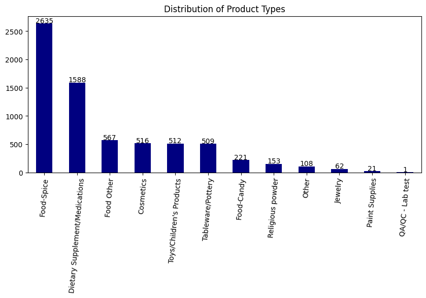

```python
#To plot bar chart
plt.figure(figsize=(10,4)) #Set size of figure
metal['Product Type'].value_counts().plot(kind='bar', color ='navy') #Plot the count of each product type as bar plot, color set to navy
plt.title('Distribution of Product Types') #Set bar plot title
plt.xlabel('')
plt.xticks(rotation = 85) #Rotate X axis labels for readability
plt.ylabel('')

#To calculate height of each bar
bar_heights = [bar.get_height() for bar in plt.gca().patches]

#To get the value of each bar and put it above the bars
for i, height in enumerate(bar_heights):
    plt.text(i, height + 10, str(height), ha='center')

plt.show()
```

DISTRIBUTION OF CONTINENTS

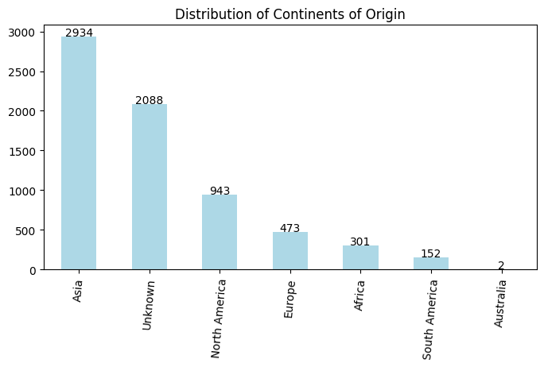

```python
plt.figure(figsize=(8,4))
metal['Continent'].value_counts().plot(kind='bar', color='lightblue')
plt.title('Distribution of Continents of Origin')
plt.xlabel('')
plt.xticks(rotation = 85)
plt.ylabel('')

#To calculate height of each bar
bar_heights = [bar.get_height() for bar in plt.gca().patches]

#To get the value of each bar and put it above the bars
for i, height in enumerate(bar_heights):
    plt.text(i, height + 10, str(height), ha='center')

plt.show()
```

COUNTRIES COUNT BY CONTINENT

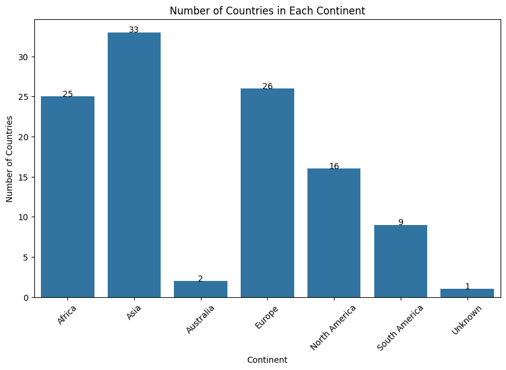

```python
# Group data by country of origin
cont_count = metal.groupby('Continent')['Country of Origin'].nunique().reset_index()

# Plot stacked bar chart
plt.figure(figsize=(10, 6))
sns.barplot(x='Continent', y='Country of Origin', data=cont_count)
plt.title('Number of Countries in Each Continent')
plt.xlabel('Continent')
plt.ylabel('Number of Countries')
plt.xticks(rotation=45)

for index, row in cont_count.iterrows():
    plt.text(index, row['Country of Origin'], str(row['Country of Origin']), color='black', ha="center")


plt.show()
```

PRODUCT TYPES BY CONTINENT

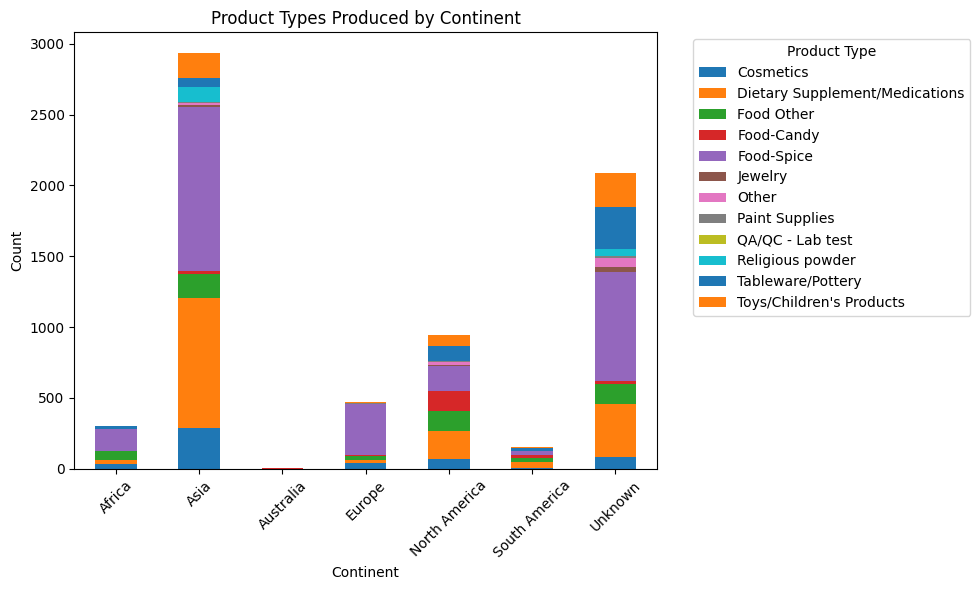

```python
# Group data by product type
grouped = metal.groupby(['Continent', 'Product Type']).size().unstack(fill_value=0)

# Plot stacked bar chart
grouped.plot(kind='bar', stacked=True, figsize=(10, 6))
plt.title('Product Types Produced by Continent')
plt.xlabel('Continent')
plt.ylabel('Count')
plt.xticks(rotation=45)

# Move legend outside the plot
plt.legend(title='Product Type', bbox_to_anchor=(1.05, 1), loc='upper left')
plt.tight_layout()  # Adjust layout to prevent overlapping
plt.show()
```

Heavy Metal Concentration of the Various Product Types

FOOD SPICES

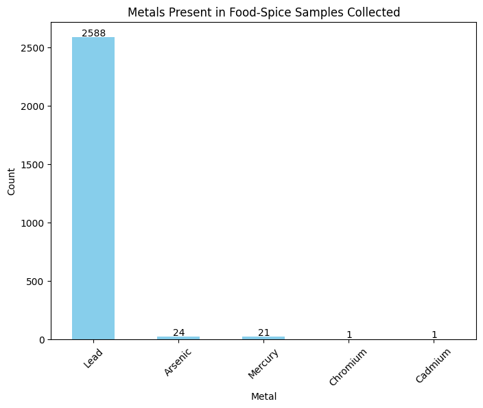

```python
# Specify the Product type
ProductType = 'Food-Spice'

# Plot the counts using a bar chart
plt.figure(figsize=(8, 6))
metal[metal['Product Type'] == ProductType]['Metal'].value_counts().plot(kind='bar', color='skyblue')
plt.title('Metals Present in ' + ProductType + ' Samples Collected')
plt.xlabel('Metal')
plt.ylabel('Count')
plt.xticks(rotation=45)


#To calculate height of each bar
bar_heights = [bar.get_height() for bar in plt.gca().patches]

#To get the value of each bar and put it above the bars
for i, height in enumerate(bar_heights):
    plt.text(i, height + 10, str(height), ha='center')

plt.show()
```

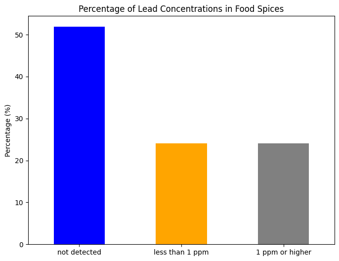

```python
#To check for the concentration of lead in food spices
# Filter the DataFrame for rows where the metal is 'Lead'
lead_spices = metal[(metal['Metal'] == 'Lead') & (metal['Product Type'] == 'Food-Spice')].copy()

# Categorize the lead concentration
lead_spices['Product Type'] = lead_spices['Concentration'].apply(lambda x: 'not detected' \
                                                                 if x == -1 else ('less than 1 ppm' if x < 1 else '1 ppm or higher'))

# Calculate the percentage of each category
category_percentages = lead_spices['Product Type'].value_counts(normalize=True) * 100

# Plotting
plt.figure(figsize=(8, 6))
category_percentages.plot(kind='bar', color=['blue', 'orange', 'gray'])
plt.title('Percentage of Lead Concentrations in Food Spices')
plt.xlabel('')
plt.ylabel('Percentage (%)')
plt.xticks(rotation=0)
plt.show()
```

Half of the food spices samples contained Lead concentration that was undetectable. About 25% contained lead in the concntrations allowed and the remaining percentage consists of those that exceeded the allowed concentration limits

FOOD CANDY

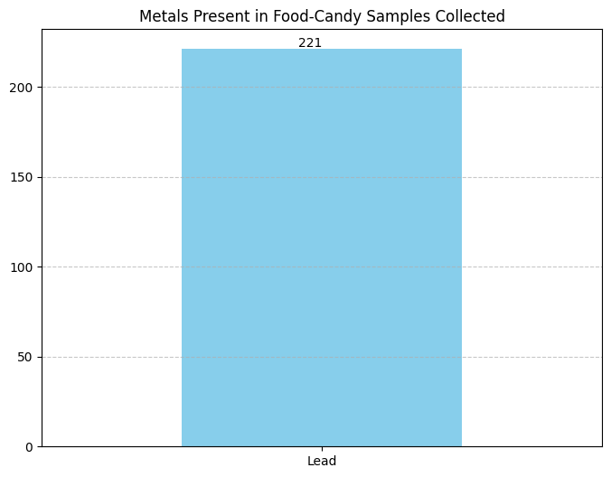

```python
# Specify the food category
ProductType = 'Food-Candy'

# Plot the counts using a bar chart
plt.figure(figsize=(8, 6))
metal[metal['Product Type'] == ProductType]['Metal'].value_counts().plot(kind='bar', color='skyblue')
plt.title('Metals Present in ' + ProductType + ' Samples Collected')
plt.xlabel('')
plt.ylabel('')
plt.xticks(rotation=0)
plt.grid(axis='y', linestyle='--', alpha=0.7)

#To calculate height of each bar
bar_heights = [bar.get_height() for bar in plt.gca().patches]

#To get the value of each bar and put it above the bars
for i, height in enumerate(bar_heights):
    plt.text(i, height + 1, str(height), ha='right')

plt.show()
```

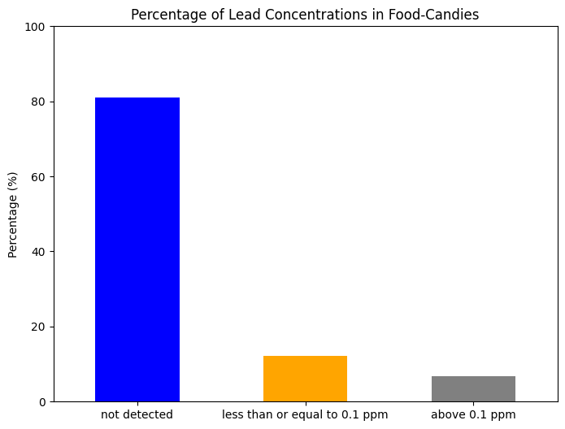

```python
#To check for the concentration of lead in food spices
# Filter the DataFrame for rows where the metal is 'Lead'
lead_candy = metal[(metal['Metal'] == 'Lead') & (metal['Product Type'] == 'Food-Candy')].copy()

# Categorize the lead concentration
lead_candy['Category'] = lead_candy['Concentration'].apply(lambda x: 'not detected' if x == -1 else\
                                                            ('less than or equal to 0.1 ppm' if x <= 1 else 'above 0.1 ppm'))


# Calculate the percentage of each category
category_percentages = lead_candy['Category'].value_counts(normalize=True) * 100

# Plotting
plt.figure(figsize=(8, 6))
category_percentages.plot(kind='bar', color=['blue', 'orange', 'gray'])
plt.title('Percentage of Lead Concentrations in Food-Candies')
plt.xlabel('')
plt.ylabel('Percentage (%)')
plt.xticks(rotation=0)
plt.ylim(0, 100)  # Ensure the y-axis starts at 0 and ends at 100 for percentages
plt.show()
```

JEWELRY

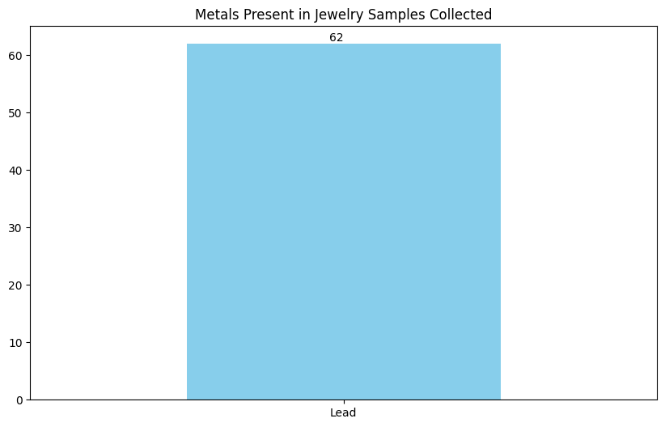

```python
# Specify the food category
ProductType = 'Jewelry'

# Plot the counts using a bar chart
plt.figure(figsize=(10, 6))
metal[metal['Product Type'] == ProductType]['Metal'].value_counts().plot(kind='bar', color='skyblue')
plt.title('Metals Present in ' + ProductType + ' Samples Collected')
plt.xlabel('')
plt.ylabel('')
plt.xticks(rotation=0)


#To calculate height of each bar
bar_heights = [bar.get_height() for bar in plt.gca().patches]

#To get the value of each bar and put it above the bars
for i, height in enumerate(bar_heights):
    plt.text(i, height + 0.5, str(height), ha='right')

plt.show()
```

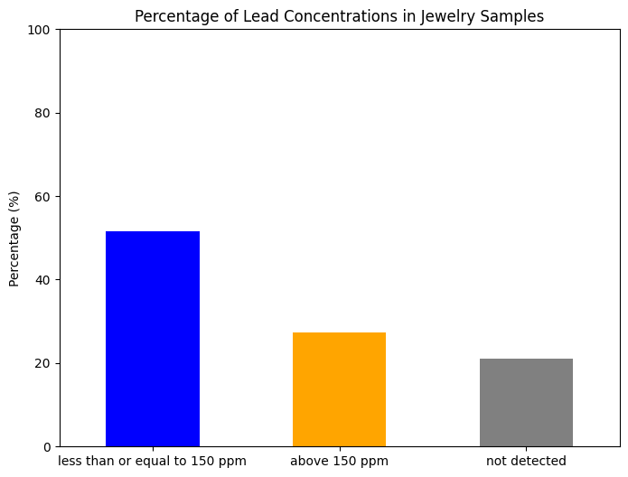

```python
#To check for the concentration of lead
# Filter the DataFrame for rows where the metal is 'Lead'
lead_jewel = metal[(metal['Metal'] == 'Lead') & (metal['Product Type'] == "Jewelry" )].copy()

# Categorize the lead concentration
lead_jewel['Category'] = lead_jewel['Concentration'].apply(lambda x: 'not detected' if x == -1 else\
                                                           ('less than or equal to 150 ppm' if x <= 150 else 'above 150 ppm'))

# Calculate the percentage of each category
category_percentages = lead_jewel['Category'].value_counts(normalize=True) * 100

# Plotting
plt.figure(figsize=(8, 6))
category_percentages.plot(kind='bar', color=['blue', 'orange', 'grey'])
plt.title('Percentage of Lead Concentrations in Jewelry Samples')
plt.xlabel('')
plt.ylabel('Percentage (%)')
plt.xticks(rotation=0)
plt.ylim(0, 100)  # Ensure the y-axis starts at 0 and ends at 100 for percentages
plt.show()
```

A little above 50% of jewelry samples contained Lead concentration within the allowed range. About 25% contained lead in concentrations that exceeded the allowed lead concentration limit in jewelries

DIETARY SUPPLEMENTS/MEDICATIONS

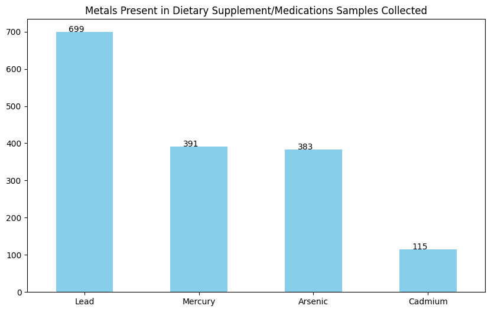

```python
# Specify the product type
ProductType = 'Dietary Supplement/Medications'

# Plot the counts using a bar chart
plt.figure(figsize=(10, 6))
metal[metal['Product Type'] == ProductType]['Metal'].value_counts().plot(kind='bar', color='skyblue')
plt.title('Metals Present in ' + ProductType + ' Samples Collected')
plt.xlabel('')
plt.ylabel('')
plt.xticks(rotation=0)


#To calculate height of each bar
bar_heights = [bar.get_height() for bar in plt.gca().patches]

#To get the value of each bar and put it above the bars
for i, height in enumerate(bar_heights):
    plt.text(i, height + 0.5, str(height), ha='right')

plt.show()
```

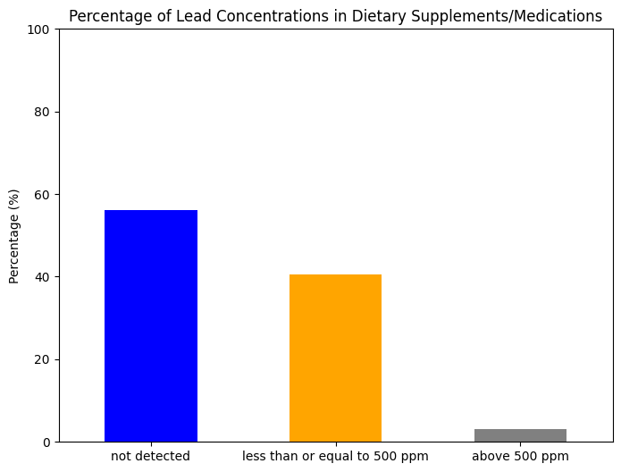

```python
#To check for the concentration of lead
# Filter the DataFrame for rows where the metal is 'Lead'
lead_med = metal[(metal['Metal'] == 'Lead') & (metal['Product Type'] == "Dietary Supplement/Medications" )].copy()

# Categorize the lead concentration
lead_med['Category'] = lead_med['Concentration'].apply(lambda x: 'not detected' if x == -1 else\
                                                       ('less than or equal to 500 ppm' if x <= 500 else 'above 500 ppm'))

# Calculate the percentage of each category
category_percentages = lead_med['Category'].value_counts(normalize=True) * 100

# Plotting
plt.figure(figsize=(8, 6))
category_percentages.plot(kind='bar', color=['blue', 'orange', 'grey'])
plt.title('Percentage of Lead Concentrations in Dietary Supplements/Medications')
plt.xlabel('')
plt.ylabel('Percentage (%)')
plt.xticks(rotation=0)
plt.ylim(0, 100)  # Ensure the y-axis starts at 0 and ends at 100 for percentages
plt.show()
```

COSMETICS

This consists of lotions, make-up products, soaps, creams, powders, body butters, nail polish, deodorants and so on.

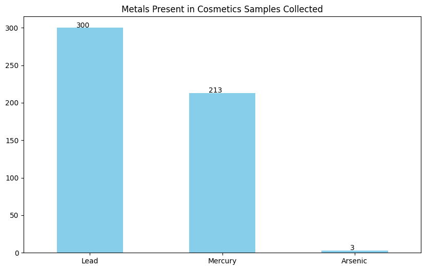

```python
# Specify the food category
ProductType = 'Cosmetics'

# Plot the counts using a bar chart
plt.figure(figsize=(10, 6))
metal[metal['Product Type'] == ProductType]['Metal'].value_counts().plot(kind='bar', color='skyblue')
plt.title('Metals Present in ' + ProductType + ' Samples Collected')
plt.xlabel('')
plt.ylabel('')
plt.xticks(rotation=0)


#To calculate height of each bar
bar_heights = [bar.get_height() for bar in plt.gca().patches]

#To get the value of each bar and put it above the bars
for i, height in enumerate(bar_heights):
    plt.text(i, height + 0.5, str(height), ha='right')

plt.show()
```

Lead is the most found heavy metal in sample cosmetics products

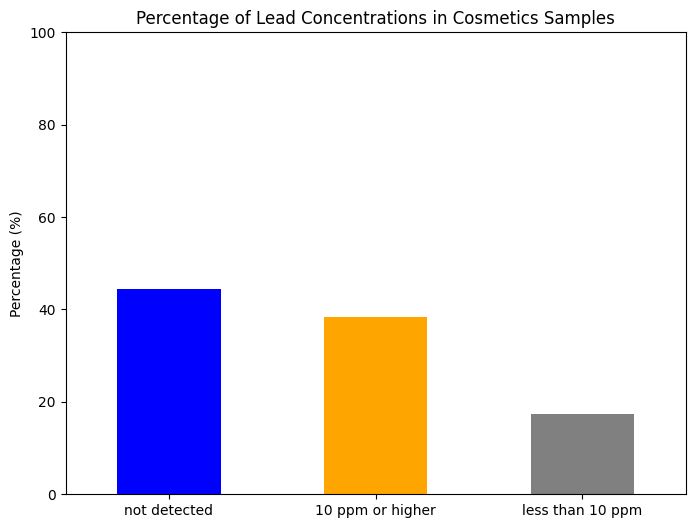

```python
#To check for the concentration of lead
# Filter the DataFrame for rows where the metal is 'Lead'
lead_cosmetics = metal[(metal['Metal'] == 'Lead') & (metal['Product Type'] == 'Cosmetics')].copy()

# Categorize the lead concentration
lead_cosmetics['Category'] = lead_cosmetics['Concentration'].apply(lambda x: 'not detected' if x == -1 else\
                                                                   ('less than 10 ppm' if x < 10 else '10 ppm or higher'))

# Calculate the percentage of each category
category_percentages = lead_cosmetics['Category'].value_counts(normalize=True) * 100

# Plotting
plt.figure(figsize=(8, 6))
category_percentages.plot(kind='bar', color=['blue', 'orange', 'grey'])
plt.title('Percentage of Lead Concentrations in Cosmetics Samples')
plt.xlabel('')
plt.ylabel('Percentage (%)')
plt.xticks(rotation=0)
plt.ylim(0, 100)  # Ensure the y-axis starts at 0 and ends at 100 for percentages
plt.show()
```

Lead was not detected in about 45% of cosmetic samples, and about 40% of the cosmetic samples exceed the allowed quantity of lead in cosmetics products

FOOD OTHER  
This category consists of food like grains, oils, seasoning cubes, fruits, vegetables,  
fish, baking products, pulses, cereals, noodles, beverages and so on.

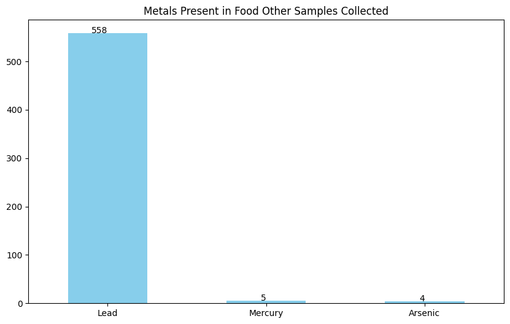

```python
# Specify the food category
ProductType = 'Food Other'

# Plot the counts using a bar chart
plt.figure(figsize=(10, 6))
metal[metal['Product Type'] == ProductType]['Metal'].value_counts().plot(kind='bar', color='skyblue')
plt.title('Metals Present in ' + ProductType + ' Samples Collected')
plt.xlabel('')
plt.ylabel('')
plt.xticks(rotation=0)


#To calculate height of each bar
bar_heights = [bar.get_height() for bar in plt.gca().patches]

#To get the value of each bar and put it above the bars
for i, height in enumerate(bar_heights):
    plt.text(i, height + 0.5, str(height), ha='right')

plt.show()
```

Major metal found in food-other product type was Lead.

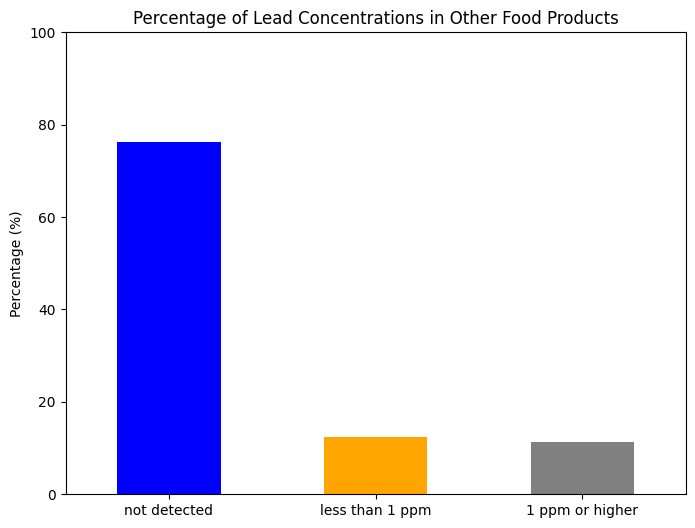

```python
#To check for the concentration of lead
# Filter the DataFrame for rows where the metal is 'Lead'
lead_food_other = metal[(metal['Metal'] == 'Lead') & (metal['Product Type'] == 'Food Other')].copy()

# Categorize the lead concentration
lead_food_other['Category'] = lead_food_other['Concentration'].apply(lambda x: 'not detected' if x == -1 else ('less than 1 ppm' if x < 1 else '1 ppm or higher'))

# Calculate the percentage of each category
category_percentages = lead_food_other['Category'].value_counts(normalize=True) * 100

# Plotting
plt.figure(figsize=(8, 6))
category_percentages.plot(kind='bar', color=['blue', 'orange', 'grey'])
plt.title('Percentage of Lead Concentrations in Other Food Products')
plt.xlabel('')
plt.ylabel('Percentage (%)')
plt.xticks(rotation=0)
plt.ylim(0, 100)  # Ensure the y-axis starts at 0 and ends at 100 for percentages
plt.show()
```

80% of Other food samples contained Lead concentration that was undetectable. About 15% contained lead in the concentrations allowed and the remaining percentage(about 10%) consists of those that exceeded the allowed concentration limits

TABLEWARE/POTTERY

This product category consists of clay pots, ceramic cups and plates, bowls, coffee mugs, ceramic jars, spoons and so on.

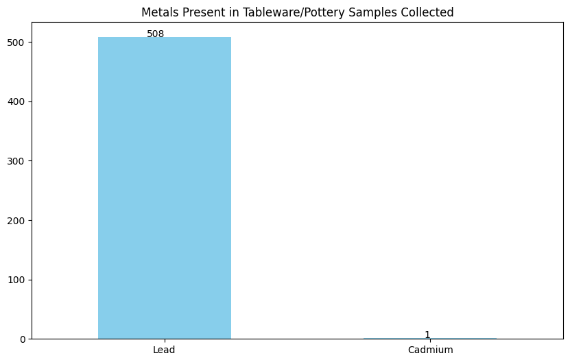

```python
# Specify the food category
ProductType = 'Tableware/Pottery'

# Plot the counts using a bar chart
plt.figure(figsize=(10, 6))
metal[metal['Product Type'] == ProductType]['Metal'].value_counts().plot(kind='bar', color='skyblue')
plt.title('Metals Present in ' + ProductType + ' Samples Collected')
plt.xlabel('')
plt.ylabel('')
plt.xticks(rotation=0)


#To calculate height of each bar
bar_heights = [bar.get_height() for bar in plt.gca().patches]

#To get the value of each bar and put it above the bars
for i, height in enumerate(bar_heights):
    plt.text(i, height + 0.5, str(height), ha='right')

plt.show()
```

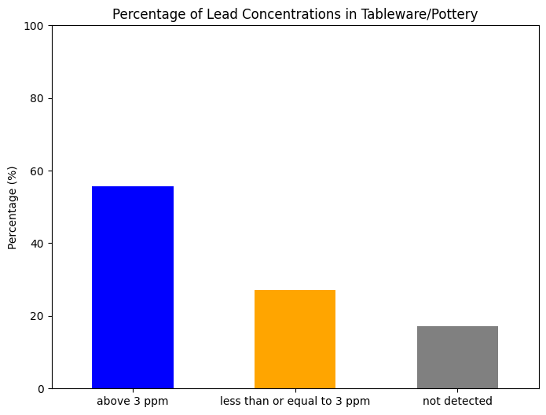

```python
#To check for the concentration of lead
# Filter the DataFrame for rows where the metal is 'Lead'
lead_pot = metal[(metal['Metal'] == 'Lead') & (metal['Product Type'] == "Tableware/Pottery" )].copy()

# Categorize the lead concentration
lead_pot['Category'] = lead_pot['Concentration'].apply(lambda x: 'not detected' if x == -1 else\
    ('less than or equal to 3 ppm' if x <= 3 else 'above 3 ppm'))

# Calculate the percentage of each category
category_percentages = lead_pot['Category'].value_counts(normalize=True) * 100

# Plotting
plt.figure(figsize=(8, 6))
category_percentages.plot(kind='bar', color=['blue', 'orange','grey'])
plt.title('Percentage of Lead Concentrations in Tableware/Pottery')
plt.xlabel('')
plt.ylabel('Percentage (%)')
plt.xticks(rotation=0)
plt.ylim(0, 100)  # Ensure the y-axis starts at 0 and ends at 100 for percentages
plt.show()
```

More than half of the tableware samples contained Lead concentration above the recommended concentration. About 25% contained lead in the concentrations allowed and the remaining percentage consists of those in which lead was not detected

TOYS/CHILDREN'S PRODUCTS

This category consists of pencils, plastic and wooden toys, ball, crayons, colouring pencils, maracas, balloons and so on.

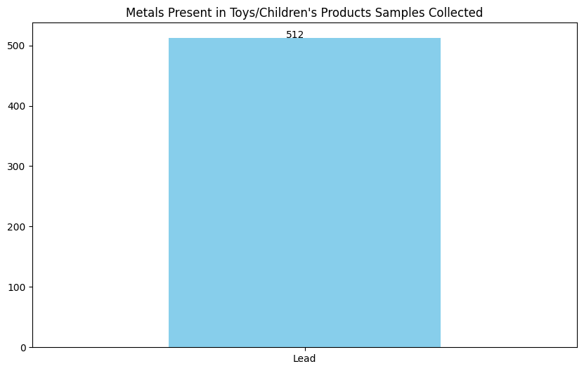

```python
# Specify the product type
ProductType = "Toys/Children's Products"

# Plot the counts using a bar chart
plt.figure(figsize=(10, 6))
metal[metal['Product Type'] == ProductType]['Metal'].value_counts().plot(kind='bar', color='skyblue')
plt.title('Metals Present in ' + ProductType + ' Samples Collected')
plt.xlabel('')
plt.ylabel('')
plt.xticks(rotation=0)


#To calculate height of each bar
bar_heights = [bar.get_height() for bar in plt.gca().patches]

#To get the value of each bar and put it above the bars
for i, height in enumerate(bar_heights):
    plt.text(i, height + 0.5, str(height), ha='right')

plt.show()
```

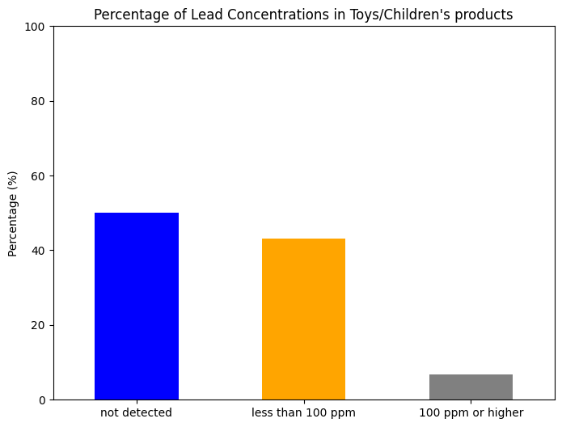

```python
#To check for the concentration of lead
# Filter the DataFrame for rows where the metal is 'Lead'
lead_toys = metal[(metal['Metal'] == 'Lead') & (metal['Product Type'] == "Toys/Children's Products" )].copy()

# Categorize the lead concentration
lead_toys['Category'] = lead_toys['Concentration'].apply(lambda x: 'not detected' if x == -1 else\
    ('less than 100 ppm' if x < 100 else '100 ppm or higher'))

# Calculate the percentage of each category
category_percentages = lead_toys['Category'].value_counts(normalize=True) * 100

# Plotting
plt.figure(figsize=(8, 6))
category_percentages.plot(kind='bar', color=['blue', 'orange', 'grey'])
plt.title("Percentage of Lead Concentrations in Toys/Children's products")
plt.xlabel('')
plt.ylabel('Percentage (%)')
plt.xticks(rotation=0)
plt.ylim(0, 100)  # Ensure the y-axis starts at 0 and ends at 100 for percentages
plt.show()
```

About 50% of Toys samples contained Lead concentration that was undetectable. A little above 40% contained lead in the concentrations allowed. Around 10% of the samples contained lead in concentrations exceeding the recommended level.

PAINT SUPPLIES

This product type consists of markers, acrylic paints, water colors and so on.

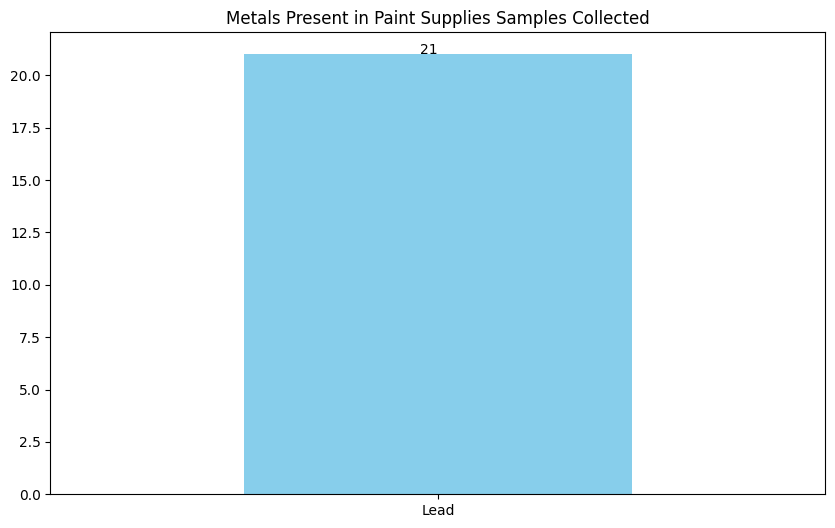

```python
# Specify the product type
ProductType = 'Paint Supplies'

# Plot the counts using a bar chart
plt.figure(figsize=(10, 6))
metal[metal['Product Type'] == ProductType]['Metal'].value_counts().plot(kind='bar', color='skyblue')
plt.title('Metals Present in ' + ProductType + ' Samples Collected')
plt.xlabel('')
plt.ylabel('')
plt.xticks(rotation=0)


#To calculate height of each bar
bar_heights = [bar.get_height() for bar in plt.gca().patches]

#To get the value of each bar and put it above the bars
for i, height in enumerate(bar_heights):
    plt.text(i, height + 0, str(height), ha='right')

plt.show()
```

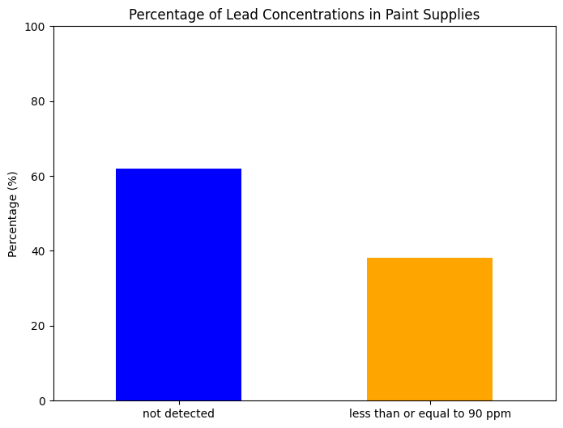

```python
#To check for the concentration of lead
# Filter the DataFrame for rows where the metal is 'Lead'
lead_paint = metal[(metal['Metal'] == 'Lead') & (metal['Product Type'] == "Paint Supplies" )].copy()

# Categorize the lead concentration
lead_paint['Category'] = lead_paint['Concentration'].apply(lambda x:'not detected' if x == -1 else\
                                                            ('less than or equal to 90 ppm' if x <= 90 else 'above 90 ppm'))

# Calculate the percentage of each category
category_percentages = lead_paint['Category'].value_counts(normalize=True) * 100

# Plotting
plt.figure(figsize=(8, 6))
category_percentages.plot(kind='bar', color=['blue', 'orange', 'grey'])
plt.title('Percentage of Lead Concentrations in Paint Supplies')
plt.xlabel('')
plt.ylabel('Percentage (%)')
plt.xticks(rotation=0)
plt.ylim(0, 100)  # Ensure the y-axis starts at 0 and ends at 100 for percentages
plt.show()
```

A little above 60% of paint supplies samples contained Lead concentration that was undetectable. About 40% contained lead in the concentrations allowed. None of the samples contained lead in concentrations exceeding the recommended level.

RELIGIOUS POWDERS

This consists of incense sticks, herbal powders, and other powders.

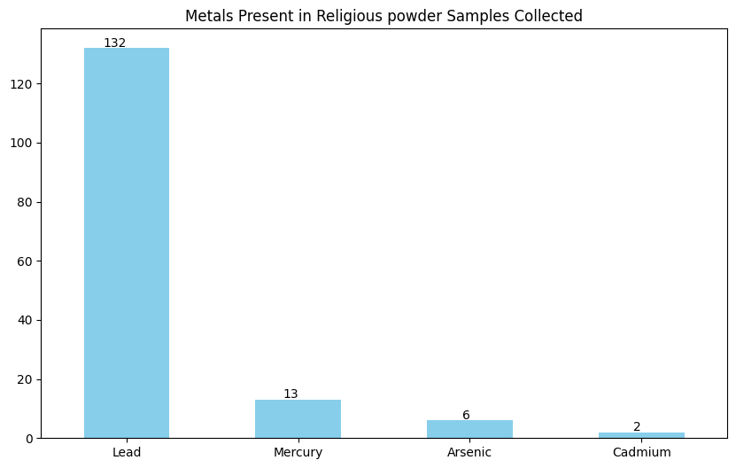

```python
# Specify the food category
ProductType = 'Religious powder'

# Plot the counts using a bar chart
plt.figure(figsize=(10, 6))
metal[metal['Product Type'] == ProductType]['Metal'].value_counts().plot(kind='bar', color='skyblue')
plt.title('Metals Present in ' + ProductType + ' Samples Collected')
plt.xlabel('')
plt.ylabel('')
plt.xticks(rotation=0)


#To calculate height of each bar
bar_heights = [bar.get_height() for bar in plt.gca().patches]

#To get the value of each bar and put it above the bars
for i, height in enumerate(bar_heights):
    plt.text(i, height + 0.5, str(height), ha='right')

plt.show()
```

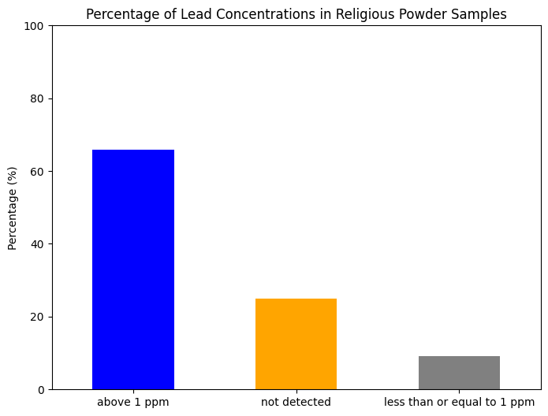

```python
#To check for the concentration of lead
# Filter the DataFrame for rows where the metal is 'Lead'
lead_powders = metal[(metal['Metal'] == 'Lead') & (metal['Product Type'] == "Religious powder" )].copy()

# Categorize the lead concentration
lead_powders['Category'] = lead_powders['Concentration'].apply(lambda x: 'not detected' if x == -1 else\
    ('less than or equal to 1 ppm' if x <= 1 else 'above 1 ppm'))

# Calculate the percentage of each category
category_percentages = lead_powders['Category'].value_counts(normalize=True) * 100

# Plotting
plt.figure(figsize=(8, 6))
category_percentages.plot(kind='bar', color=['blue', 'orange', 'grey'])
plt.title('Percentage of Lead Concentrations in Religious Powder Samples')
plt.xlabel('')
plt.ylabel('Percentage (%)')
plt.xticks(rotation=0)
plt.ylim(0, 100)  # Ensure the y-axis starts at 0 and ends at 100 for percentages
plt.show()
```

Above 65% of Religious powder samples contained Lead concentration in levels exceeding the allowed concentration.Lead was not detected in about 25% of the samples, and about 10% contained lead in concentrations within the recommended level.

```python
metal['Product Type'].unique()
```

```
array(['Food-Spice', 'Food-Candy', 'Jewelry', 'Cosmetics',
       'Dietary Supplement/Medications', 'Food Other',
       'Tableware/Pottery', "Toys/Children's Products",
       'Religious powder', 'Other', 'Paint Supplies', 'QA/QC - Lab test'],
      dtype=object)
```

```python
#To create a table showing the approved lead concentration levels for each product type

# Define the data for the table
#Create dictionary called productconc
productConc = {
    'Product_Type': ['Food-Spice', 'Food-Candy', 'Jewelry', 'Cosmetics', 'Dietary Supplement/Medications', 'Food Other',
       'Tableware/Pottery', "Toys/Children's Products",  'Religious Powders', 'Paint Supplies'],
    'ApprovedConcentration_(ppm)': [1, 0.1, 150, 10, 500, 1, 3, 100, 1, 90]  # Assuming units are in ppm
}

# Create a DataFrame
df = pd.DataFrame(productConc)

# Display the DataFrame
print(df)
```

```
                     Product_Type  ApprovedConcentration_(ppm)
0                      Food-Spice                          1.0
1                      Food-Candy                          0.1
2                         Jewelry                        150.0
3                       Cosmetics                         10.0
4  Dietary Supplement/Medications                        500.0
5                      Food Other                          1.0
6               Tableware/Pottery                          3.0
7        Toys/Children's Products                        100.0
8               Religious Powders                          1.0
9                  Paint Supplies                         90.0
```

CONCLUSION

In conclusion, our analysis sheds light on the metal content of consumer products across New York City. The dominance of food spices among the samples underscores their significant presence in the local market and stores. Moreover, the prevalence of products originating from Asian countries highlights the nature of the supply chain.

REFERENCES

Compliance Gate. (2023, April). Heavy metal regulations in the United States. Retrieved from https://www.compliancegate.com/heavy-metal-regulations-united-states/

Gautam, A., & Cressey, P. (2022, November). Health risk assessment: Heavy metals (lead, cadmium and nickel) in jewellery (oral and dermal contact) (Client Report No. FW22035). ESR Risk Assessment and Social Systems Group. Reviewed by Dr. Jeff Fowles, Tox-Logic. Prepared for Ministry of Health.

Ishida, M. L., Greene, V., King, T., Greenberg, J., Luker, J., Oglesby, D., Sheridan, R., & Trodden, J. (2022). Regulatory policies for heavy metals in spices – a New York approach. Journal of Regulatory Science, 10(1), 1–12. Retrieved from http://journalofregulatoryscience.org

U.S. Food and Drug Administration. (n.d.). Environmental contaminants in food. Retrieved from https://www.fda.gov/food/chemical-contaminants-pesticides/environmental-contaminants-food

U.S. Food and Drug Administration. (n.d.). Title 21: Food and Drugs. Part 172—Food additives permitted for direct addition to food for human consumption. Retrieved from https://www.accessdata.fda.gov/scripts/cdrh/cfdocs/cfcfr/CFRSearch.cfm?CFRPart=172&showFR=1